# Chicago Tree Data (DuPage County)

**Note: missing values for certain predictors were coerced to the mean value (eg HEIGHT_MAX, DBH_IN)**

# 1 Top 10 species - single predictor modeled

## 1.1 BLDG_AGE

Modeled predictors: BLDG_AGE  
Plotted predictor (all others held at their mean value:) BLDG_AGE

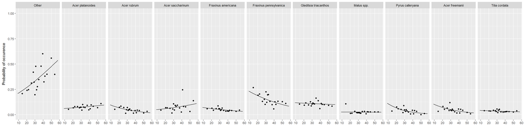

## 1.2 HU_DENS

Modeled predictors: HU_DENS  
Plotted predictor (all others held at their mean value:) HU_DENS

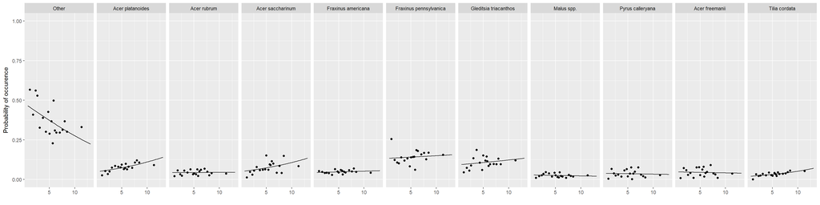

## 1.3 DIST_WATER

Modeled predictors: DIST_WATER  
Plotted predictor (all others held at their mean value:) DIST_WATER

## 1.4 DIST_MINOR

Modeled predictors: DIST_MINOR  
Plotted predictor (all others held at their mean value:) DIST_MINOR

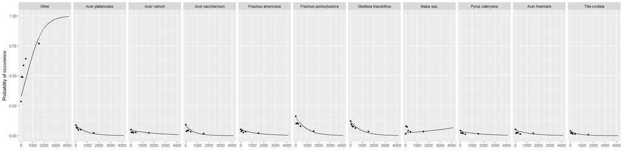

## 1.5 DIST_MAJOR

Modeled predictors: DIST_MAJOR  
Plotted predictor (all others held at their mean value:) DIST_MAJOR

## 1.6 PD

Modeled predictors: PD  
Plotted predictor (all others held at their mean value:) PD

[figure not shown]

## 1.7 LPI

Modeled predictors: LPI  
Plotted predictor (all others held at their mean value:) LPI

[figure not shown]

## 1.8 LSI

Modeled predictors: LSI  
Plotted predictor (all others held at their mean value:) LSI

[figure not shown]

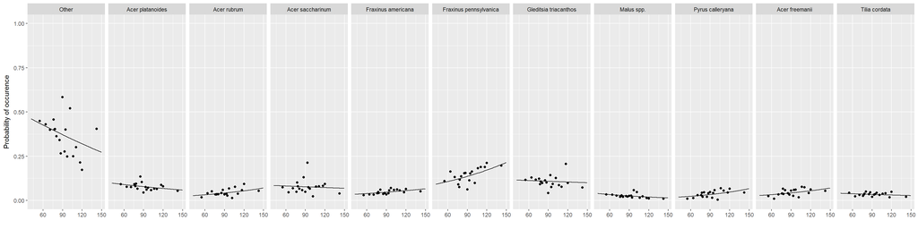

## 1.9 CROWN_AREA

Modeled predictors: CROWN_AREA  
Plotted predictor (all others held at their mean value:) CROWN_AREA

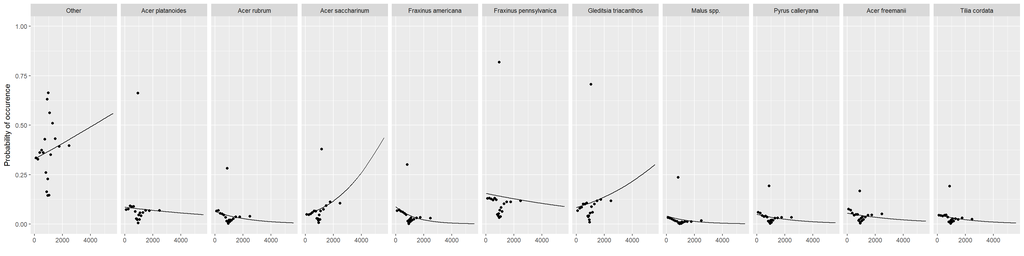

## 1.10 CROWN_COMPACTNESS

Modeled predictors: CROWN_COMPACTNESS  
Plotted predictor (all others held at their mean value:) CROWN_COMPACTNESS

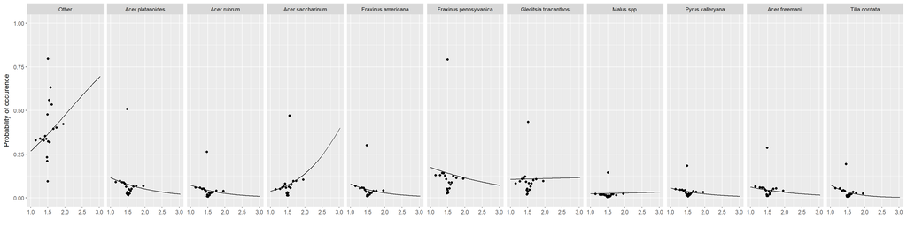

## 1.11 HEIGHT_MAX

Modeled predictors: HEIGHT_MAX  
Plotted predictor (all others held at their mean value:) HEIGHT_MAX

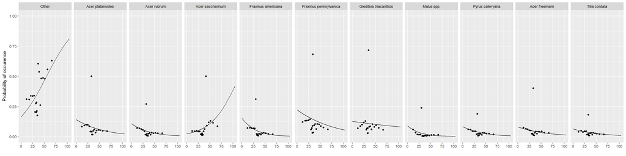

## 1.12 HEIGHT_MEAN

Modeled predictors: HEIGHT_MEAN  
Plotted predictor (all others held at their mean value:) HEIGHT_MEAN

## 1.13 RELBORDER_TREE

Modeled predictors: RELBORDER_TREE  
Plotted predictor (all others held at their mean value:) RELBORDER_TREE

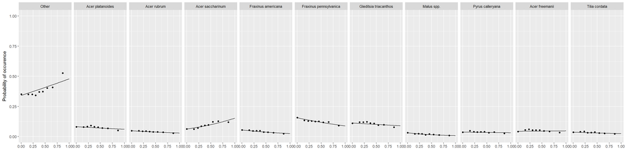

## 1.14 DBH_IN

Modeled predictors: DBH_IN  
Plotted predictor (all others held at their mean value:) DBH_IN

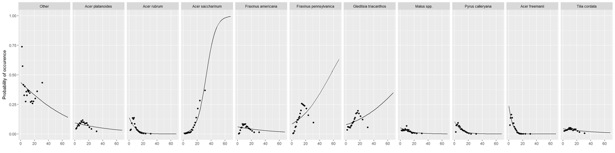

# 2 Top 10 species - all predictors modeled

## 2.1 BLDG_AGE

Modeled predictors: BLDG_AGE+HU_DENS+DIST_WATER+DIST_MINOR+DIST_MAJOR+PD+LPI+LSI+CROWN_AREA+CROWN_COMPACTNESS+HEIGHT_MAX+HEIGHT_MEAN+RELBORDER_TREE+DBH_IN  
Plotted predictor (all others held at their mean value): BLDG_AGE

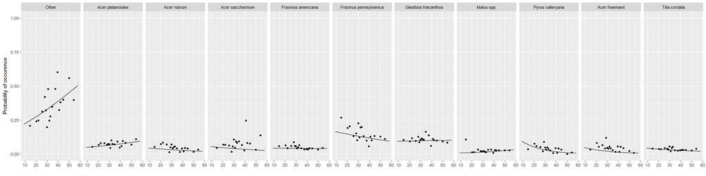

## 2.2 HU_DENS

Modeled predictors: BLDG_AGE+HU_DENS+DIST_WATER+DIST_MINOR+DIST_MAJOR+PD+LPI+LSI+CROWN_AREA+CROWN_COMPACTNESS+HEIGHT_MAX+HEIGHT_MEAN+RELBORDER_TREE+DBH_IN  
Plotted predictor (all others held at their mean value): HU_DENS

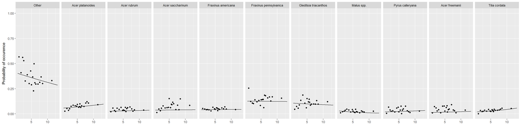

## 2.3 DIST_WATER

Modeled predictors: BLDG_AGE+HU_DENS+DIST_WATER+DIST_MINOR+DIST_MAJOR+PD+LPI+LSI+CROWN_AREA+CROWN_COMPACTNESS+HEIGHT_MAX+HEIGHT_MEAN+RELBORDER_TREE+DBH_IN  
Plotted predictor (all others held at their mean value): DIST_WATER

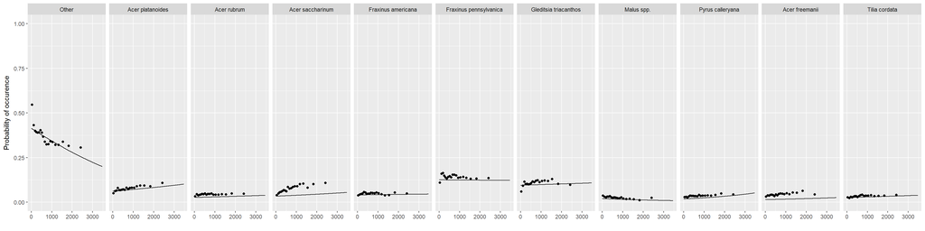

## 2.4 DIST_MINOR

Modeled predictors: BLDG_AGE+HU_DENS+DIST_WATER+DIST_MINOR+DIST_MAJOR+PD+LPI+LSI+CROWN_AREA+CROWN_COMPACTNESS+HEIGHT_MAX+HEIGHT_MEAN+RELBORDER_TREE+DBH_IN  
Plotted predictor (all others held at their mean value): DIST_MINOR

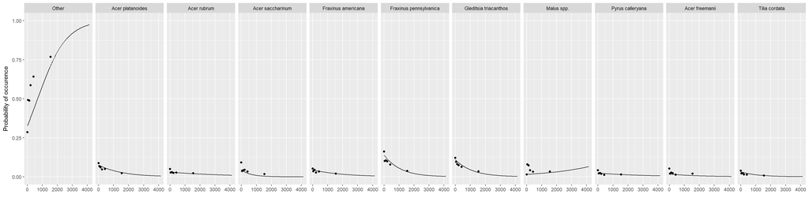

## 2.5 DIST_MAJOR

Modeled predictors: BLDG_AGE+HU_DENS+DIST_WATER+DIST_MINOR+DIST_MAJOR+PD+LPI+LSI+CROWN_AREA+CROWN_COMPACTNESS+HEIGHT_MAX+HEIGHT_MEAN+RELBORDER_TREE+DBH_IN  
Plotted predictor (all others held at their mean value): DIST_MAJOR

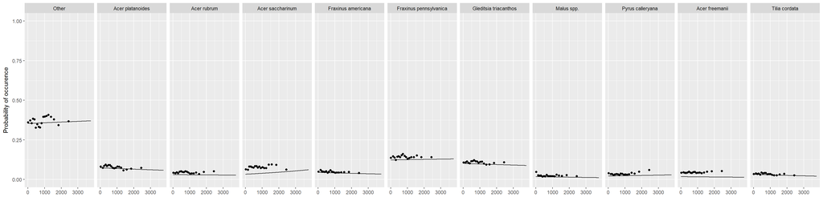

## 2.6 PD

Modeled predictors: BLDG_AGE+HU_DENS+DIST_WATER+DIST_MINOR+DIST_MAJOR+PD+LPI+LSI+CROWN_AREA+CROWN_COMPACTNESS+HEIGHT_MAX+HEIGHT_MEAN+RELBORDER_TREE+DBH_IN  
Plotted predictor (all others held at their mean value): PD

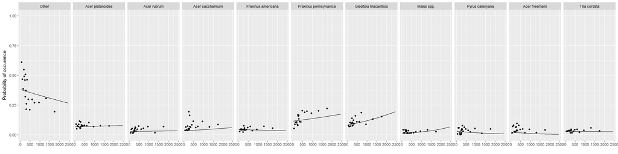

## 2.7 LPI

Modeled predictors: BLDG_AGE+HU_DENS+DIST_WATER+DIST_MINOR+DIST_MAJOR+PD+LPI+LSI+CROWN_AREA+CROWN_COMPACTNESS+HEIGHT_MAX+HEIGHT_MEAN+RELBORDER_TREE+DBH_IN  
Plotted predictor (all others held at their mean value): LPI

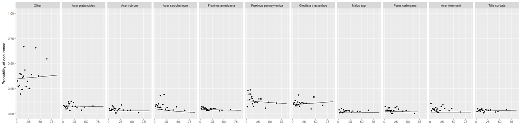

## 2.8 LSI

Modeled predictors: BLDG_AGE+HU_DENS+DIST_WATER+DIST_MINOR+DIST_MAJOR+PD+LPI+LSI+CROWN_AREA+CROWN_COMPACTNESS+HEIGHT_MAX+HEIGHT_MEAN+RELBORDER_TREE+DBH_IN  
Plotted predictor (all others held at their mean value): LSI

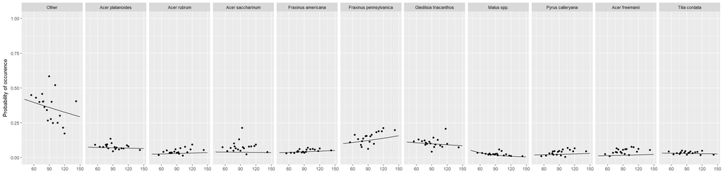

## 2.9 CROWN_AREA

Modeled predictors: BLDG_AGE+HU_DENS+DIST_WATER+DIST_MINOR+DIST_MAJOR+PD+LPI+LSI+CROWN_AREA+CROWN_COMPACTNESS+HEIGHT_MAX+HEIGHT_MEAN+RELBORDER_TREE+DBH_IN  
Plotted predictor (all others held at their mean value): CROWN_AREA

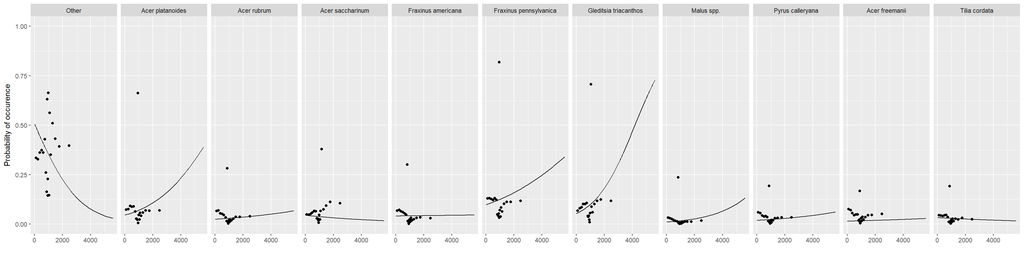

## 2.10 CROWN_COMPACTNESS

Modeled predictors: BLDG_AGE+HU_DENS+DIST_WATER+DIST_MINOR+DIST_MAJOR+PD+LPI+LSI+CROWN_AREA+CROWN_COMPACTNESS+HEIGHT_MAX+HEIGHT_MEAN+RELBORDER_TREE+DBH_IN  
Plotted predictor (all others held at their mean value): CROWN_COMPACTNESS

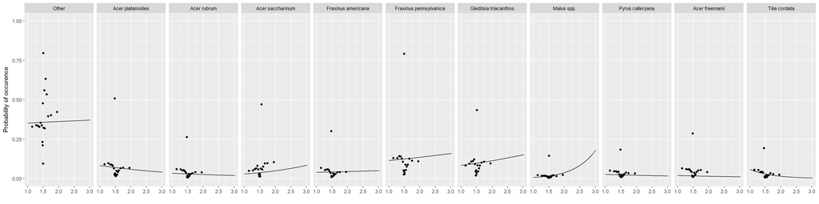

## 2.11 HEIGHT_MAX

Modeled predictors: BLDG_AGE+HU_DENS+DIST_WATER+DIST_MINOR+DIST_MAJOR+PD+LPI+LSI+CROWN_AREA+CROWN_COMPACTNESS+HEIGHT_MAX+HEIGHT_MEAN+RELBORDER_TREE+DBH_IN  
Plotted predictor (all others held at their mean value): HEIGHT_MAX

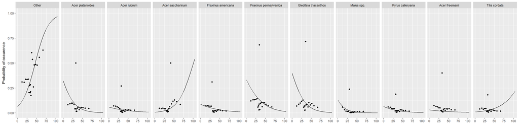

## 2.12 HEIGHT_MEAN

Modeled predictors: BLDG_AGE+HU_DENS+DIST_WATER+DIST_MINOR+DIST_MAJOR+PD+LPI+LSI+CROWN_AREA+CROWN_COMPACTNESS+HEIGHT_MAX+HEIGHT_MEAN+RELBORDER_TREE+DBH_IN  
Plotted predictor (all others held at their mean value): HEIGHT_MEAN

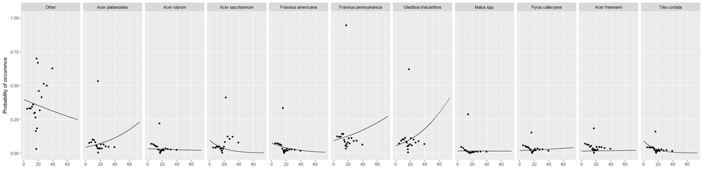

## 2.13 RELBORDER_TREE

Modeled predictors: BLDG_AGE+HU_DENS+DIST_WATER+DIST_MINOR+DIST_MAJOR+PD+LPI+LSI+CROWN_AREA+CROWN_COMPACTNESS+HEIGHT_MAX+HEIGHT_MEAN+RELBORDER_TREE+DBH_IN  
Plotted predictor (all others held at their mean value): RELBORDER_TREE

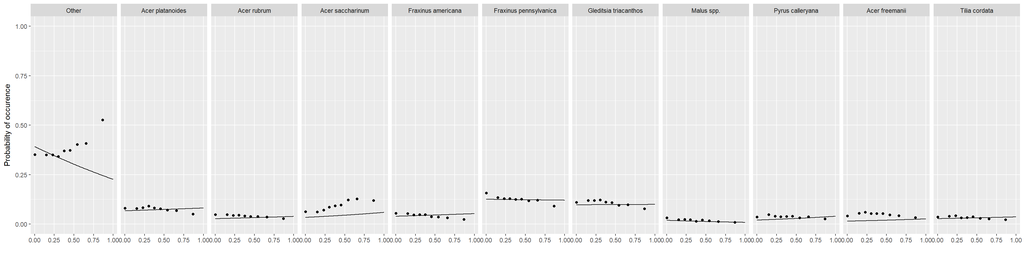

## 2.14 DBH_IN

Modeled predictors: BLDG_AGE+HU_DENS+DIST_WATER+DIST_MINOR+DIST_MAJOR+PD+LPI+LSI+CROWN_AREA+CROWN_COMPACTNESS+HEIGHT_MAX+HEIGHT_MEAN+RELBORDER_TREE+DBH_IN  
Plotted predictor (all others held at their mean value): DBH_IN

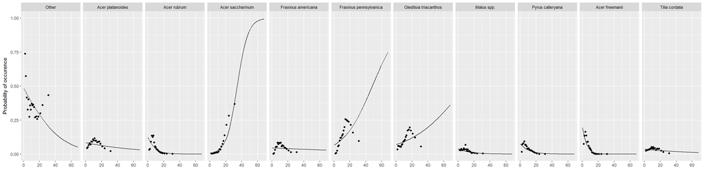